# Analysis of Pierce County House Sales

Henry Shaw & Saransh Rakshak

Due: September 3rd, 2024

Below is a breakdown of four variables within the Pierce County House Sales data set provided. We decided to choose House Square Feet, Bedrooms, Bathrooms, and Year Built for our four fields to review.

Correlation of Variables with Sale Price Under $1M

|  | sale_price | house_square_feet | year_built | bedrooms | bathrooms |
| --- | --- | --- | --- | --- | --- |
| Correlation | 1 | 0.6353549 | 0.5056716 | 0.3404705 | 0.3212723 |

For our variable that shows the highest correlation to sales price, we decided to plot a histogram for House Square Feet.

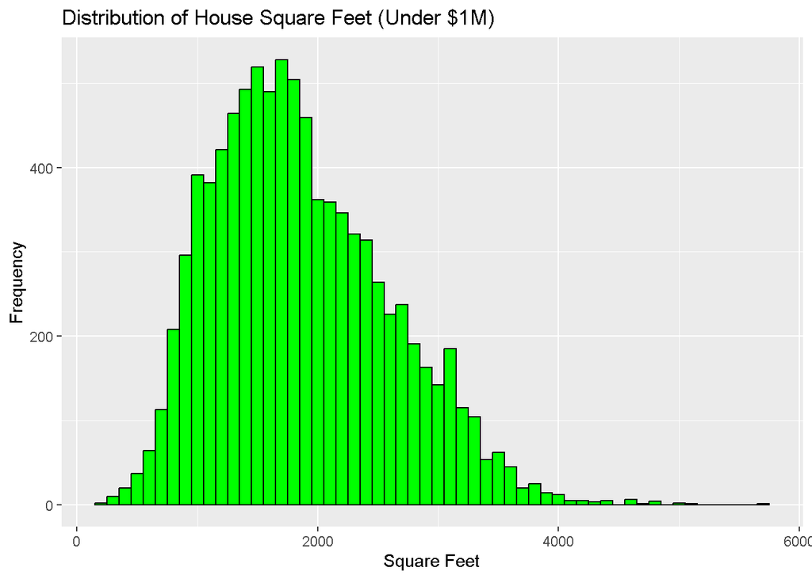

Summary Statistics of House Square Feet

| Mean Square Feet | Median Square Feet | SD of Square Feet | Min Square Feet | Max Square Feet |
| --- | --- | --- | --- | --- |
| 1,863 | 1,762 | 727 | 216 | 5,686 |

Additional Summary Statistics of House Square Feet

| SD of Square Feet | Range | IQR | Skewness | Kurtosis |
| --- | --- | --- | --- | --- |
| 726.76 | 5470.00 | 1014.00 | 0.59 | 0.10 |

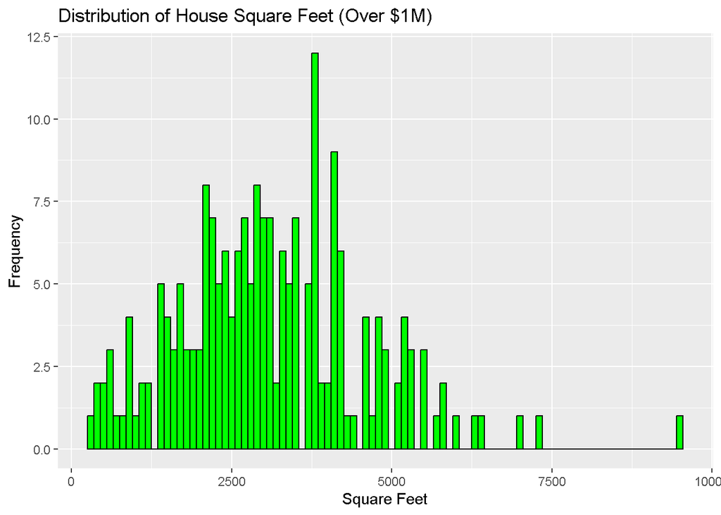

Summary Statistics of House Square Feet

| Mean Square Feet | Median Square Feet | SD of Square Feet | Min Square Feet | Max Square Feet |
| --- | --- | --- | --- | --- |
| 3,100 | 3,000 | 1,449 | 312 | 9,510 |

Additional Summary Statistics of House Square Feet

| SD of Square Feet | Range | IQR | Skewness | Kurtosis |
| --- | --- | --- | --- | --- |
| 1449.08 | 9198.00 | 1825.75 | 0.64 | 1.20 |

- Similar to houses sold under $1M, there is a Right Skewed trend and a higher distribution sold for houses under 5000 square feet. However, the spread of data is not nearly as uniform as with the houses under $1M. Additionally, the skewness is slightly greater (0.64) vs (0.59) than that for houses under 1M.

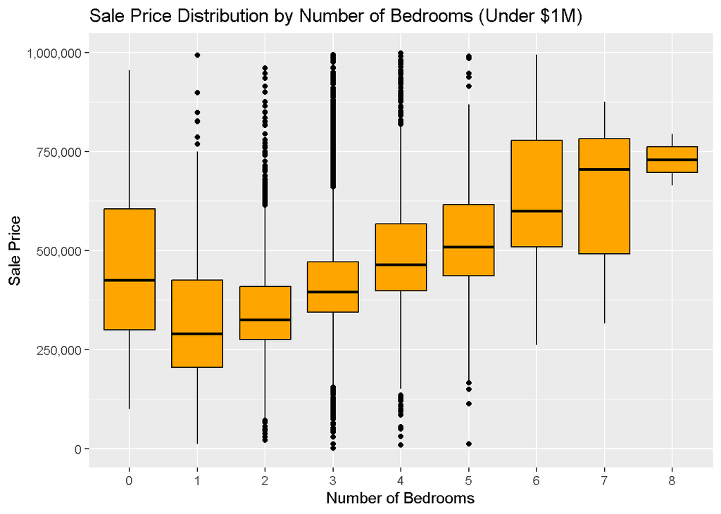

Summary Statistics for Sale Price by Number of Bedrooms

| Bedrooms | Count | Mean Sale Price | Median Sale Price | SD of Sale Price | Min Sale Price | Max Sale Price |
| --- | --- | --- | --- | --- | --- | --- |
| 0 | 29 | 455,076 | 425,000 | 222,776 | 100,000 | 955,000 |
| 1 | 169 | 340,867 | 290,000 | 191,608 | 12,000 | 992,500 |
| 2 | 1010 | 355,628 | 325,000 | 150,149 | 22,000 | 960,000 |
| 3 | 4578 | 422,227 | 396,250 | 140,965 | 2,000 | 995,000 |
| 4 | 2574 | 492,383 | 464,998 | 148,553 | 10,000 | 999,000 |
| 5 | 568 | 528,471 | 510,000 | 142,436 | 12,752 | 990,000 |
| 6 | 54 | 622,163 | 600,000 | 184,286 | 262,500 | 994,990 |
| 7 | 10 | 643,153 | 705,000 | 185,719 | 316,000 | 875,990 |
| 8 | 2 | 730,000 | 730,000 | 91,924 | 665,000 | 795,000 |

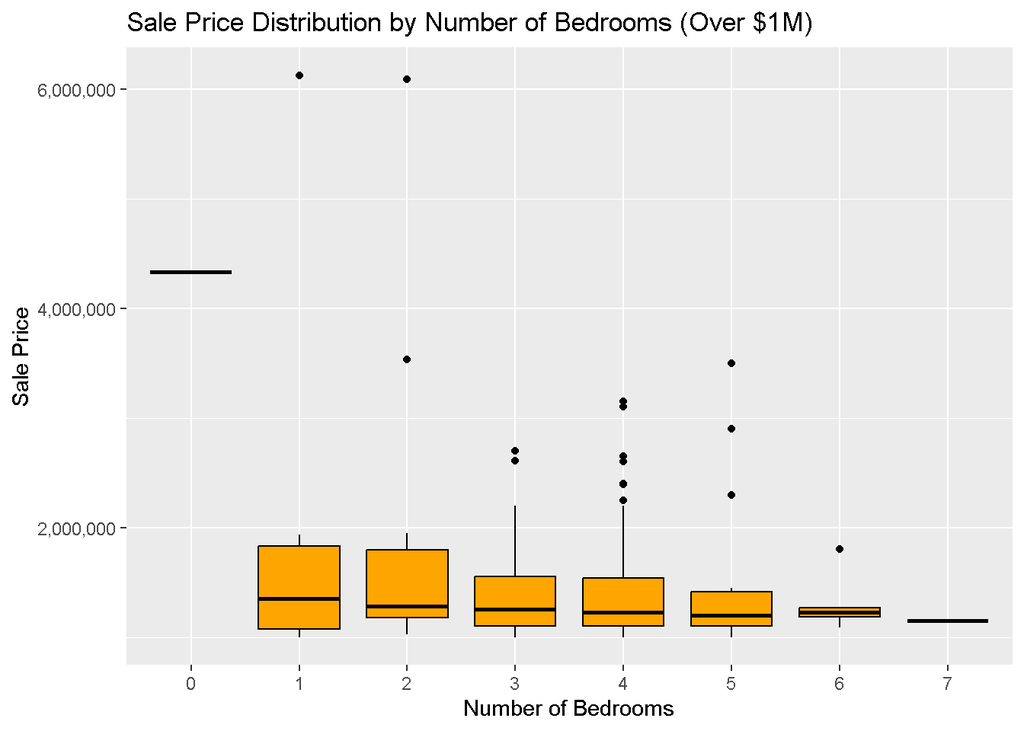

Summary Statistics for Sale Price by Number of Bedrooms

| Bedrooms | Count | Mean Sale Price | Median Sale Price | SD of Sale Price | Min Sale Price | Max Sale Price |
| --- | --- | --- | --- | --- | --- | --- |
| 0 | 1 | 4,334,100 | 4,334,100 | NA | 4,334,100 | 4,334,100 |
| 1 | 10 | 1,860,050 | 1,350,000 | 1,541,223 | 1,000,000 | 6,130,000 |
| 2 | 21 | 1,699,939 | 1,280,000 | 1,145,075 | 1,025,000 | 6,090,000 |
| 3 | 73 | 1,375,113 | 1,253,000 | 370,039 | 1,000,000 | 2,700,000 |
| 4 | 79 | 1,423,370 | 1,225,000 | 480,673 | 1,000,000 | 3,150,000 |
| 5 | 16 | 1,503,619 | 1,194,950 | 738,934 | 1,000,000 | 3,500,000 |
| 6 | 5 | 1,312,018 | 1,225,000 | 280,613 | 1,088,000 | 1,800,000 |
| 7 | 1 | 1,147,500 | 1,147,500 | NA | 1,147,500 | 1,147,500 |

- Unlike with house_sales under $1M, houses that sold for over $1M showed the opposite trend, with sales price decreasing as the number of rooms increases. There is also an outliar for when number of bedrooms is equal to 0. This may be caused by the purchasing of land or an un-built houses which does not have any officially listed ‘rooms’, rather just a property of land.

For Bathrooms, we decided to create a Box Plot.

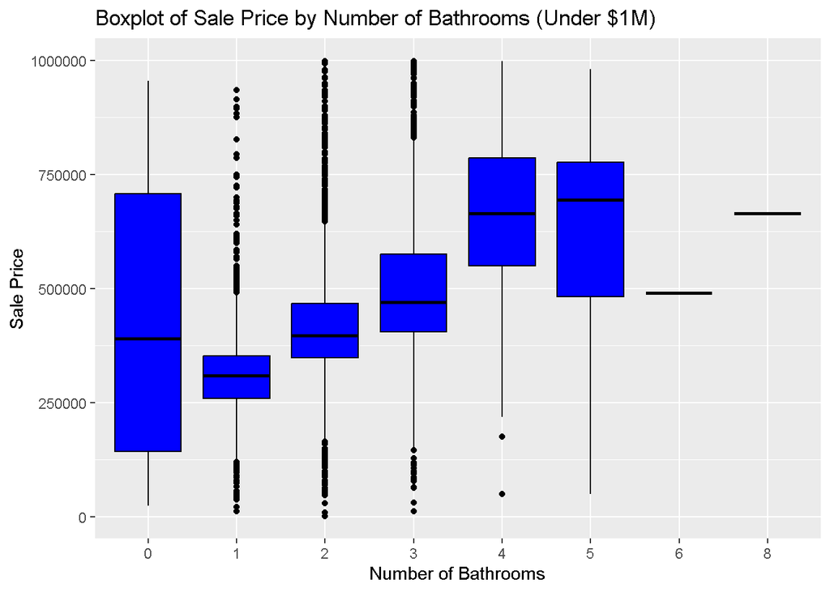

Summary Statistics for Sale Price by Number of Bathrooms

| Bathrooms | Count | Mean Sale Price | Median Sale Price | SD of Sale Price | Min Sale Price | Max Sale Price |
| --- | --- | --- | --- | --- | --- | --- |
| 0 | 16 | 429,125 | 390,000 | 300,601 | 25,000 | 955,000 |
| 1 | 1579 | 311,396 | 310,000 | 108,729 | 12,000 | 935,000 |
| 2 | 3412 | 417,329 | 396,750 | 127,919 | 2,000 | 999,000 |
| 3 | 3648 | 500,544 | 470,000 | 141,450 | 12,000 | 998,950 |
| 4 | 309 | 662,123 | 664,990 | 162,926 | 50,000 | 998,000 |
| 5 | 28 | 634,726 | 694,500 | 216,808 | 50,412 | 980,500 |
| 6 | 1 | 489,950 | 489,950 | NA | 489,950 | 489,950 |
| 8 | 1 | 665,000 | 665,000 | NA | 665,000 | 665,000 |

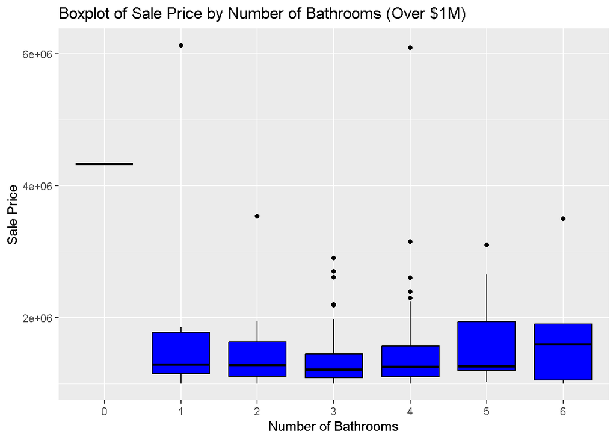

Summary Statistics for Sale Price by Number of Bathrooms

| Bathrooms | Count | Mean Sale Price | Median Sale Price | SD of Sale Price | Min Sale Price | Max Sale Price |
| --- | --- | --- | --- | --- | --- | --- |
| 0 | 1 | 4,334,100 | 4,334,100 | NA | 4,334,100 | 4,334,100 |
| 1 | 16 | 1,676,875 | 1,290,000 | 1,224,802 | 1,000,000 | 6,130,000 |
| 2 | 24 | 1,455,559 | 1,282,500 | 536,559 | 1,000,000 | 3,531,723 |
| 3 | 88 | 1,341,220 | 1,212,500 | 383,666 | 1,000,000 | 2,900,000 |
| 4 | 56 | 1,500,746 | 1,251,500 | 766,967 | 1,000,000 | 6,090,000 |
| 5 | 16 | 1,626,224 | 1,262,500 | 637,805 | 1,025,000 | 3,100,000 |
| 6 | 5 | 1,808,400 | 1,592,000 | 1,018,014 | 1,000,000 | 3,500,000 |

- Unlike houses that are sold for under $1M, for sales over $1M, there are an extremely small amount of purchases for properties with no bathrooms. This again can be explained by the client purchasing an undeveloped area of land which may have no bedrooms or bathrooms. Also, sales price stays relatively constant even with the addition of bathrooms, showing that the amount of bathrooms in a house may not be a big factors for home-seekers willing to pay over $1M.

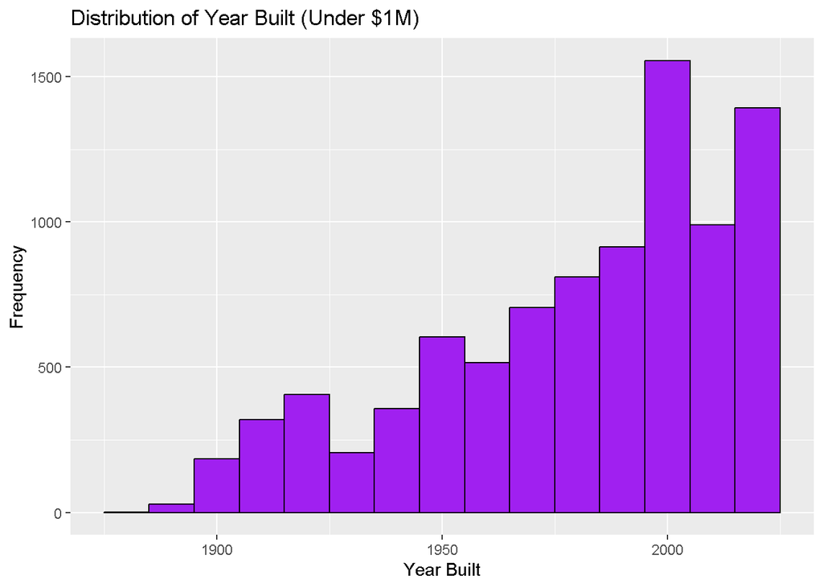

Summary Statistics of Year Built

| Mean Year Built | Median Year Built | Min Year Built | Max Year Built |
| --- | --- | --- | --- |
| 1980.534 | 1990 | 1880 | 2021 |

Additional Summary Statistics of Year Built

| SD of Year Built | Range | IQR | Skewness | Kurtosis |
| --- | --- | --- | --- | --- |
| 33.41 | 141.00 | 47.00 | -0.77 | -0.41 |

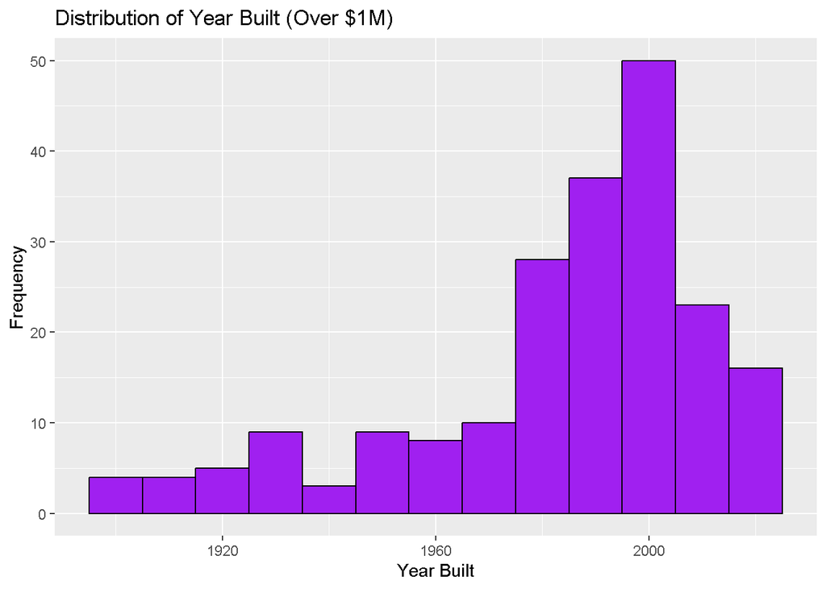

Summary Statistics of Year Built

| Mean Year Built | Median Year Built | Min Year Built | Max Year Built |
| --- | --- | --- | --- |
| 1983.767 | 1991 | 1900 | 2021 |

Additional Summary Statistics of Year Built

| SD of Year Built | Range | IQR | Skewness | Kurtosis |
| --- | --- | --- | --- | --- |
| 28.31 | 121.00 | 27.75 | -1.20 | 0.75 |

- Similar to houses under $1M, our distribution is left-skewed, showing that regardless of purchasing budgets, home-seekers prefer to purchase newly developed housing.

Grid of all Plots (Under $1M)

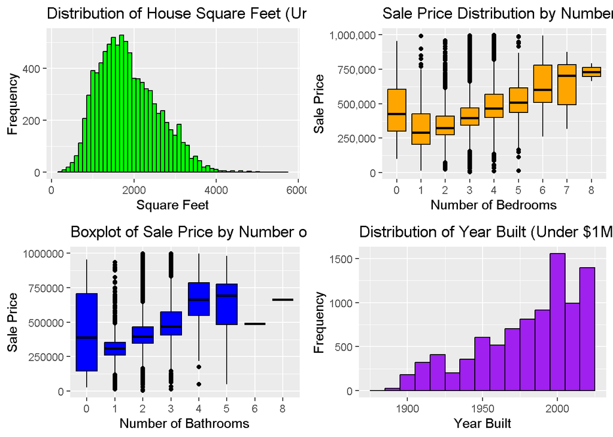

Grid of all Plots (Over $1M)

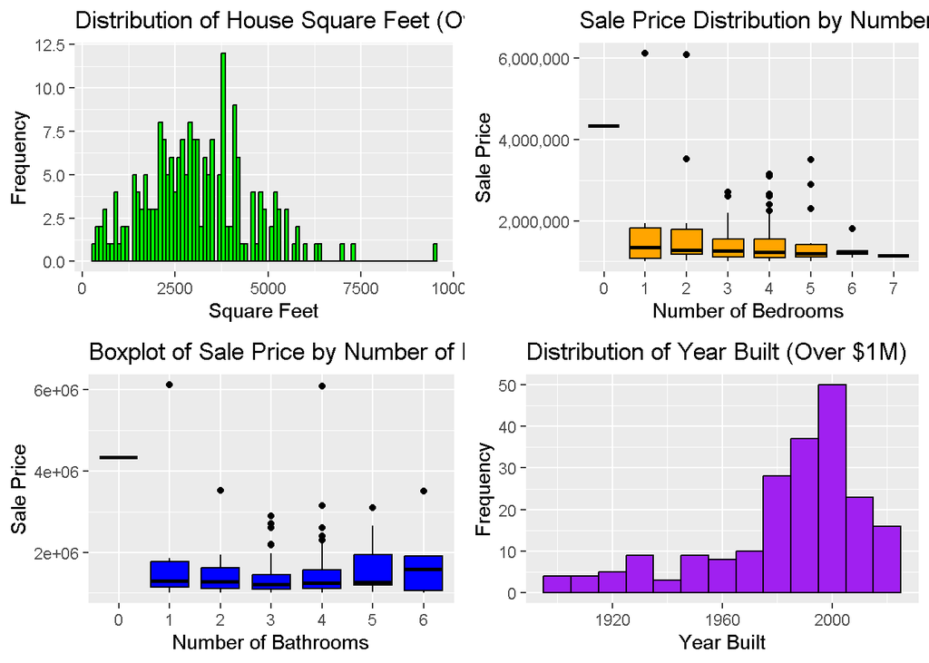